# HousePriceDataAnalysis

# **Análisis Exploratorio de Datos(Dataset Limpio)**

## Boxplots

### Price y Bedrooms

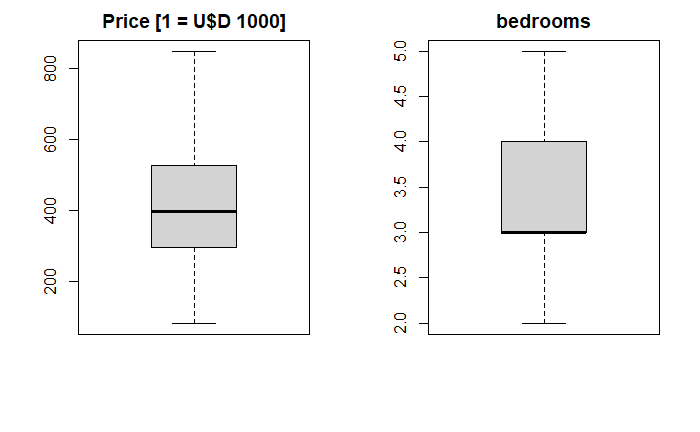

```r
par(mfrow=c(1,2))
boxplot(dataset$price/1000,main="Price [1 = U$D 1000]")
boxplot(dataset$bedrooms,main="bedrooms")
```

### Bathrooms

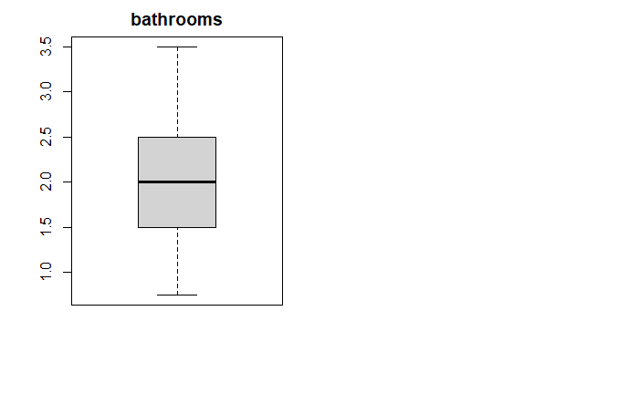

```r
par(mfrow=c(1,2))
boxplot(dataset$bathrooms,main="bathrooms")
```

### Sqft_lot y Sqft_lot15

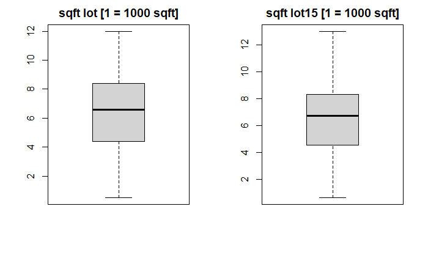

```r
par(mfrow=c(1,2))
boxplot(dataset$sqft_lot/1000,main="sqft lot [1 = 1000 sqft]")
boxplot(dataset$sqft_lot15/1000,main="sqft lot15 [1 = 1000 sqft]")
```

### Floors y Sqft_above

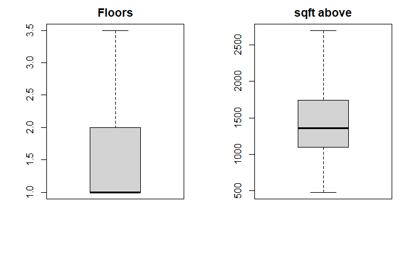

```r
par(mfrow=c(1,2))
boxplot(dataset$floors,main="Floors")
boxplot(dataset$sqft_above,main="sqft above")
```

### Sqft_living y Sqft_living15

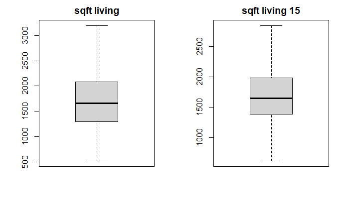

```r
par(mfrow=c(1,2))
boxplot(dataset$sqft_living,main="sqft living")

boxplot(dataset$sqft_living15,main="sqft living 15")
```

## Pieplots

### Renovated y Has_basement

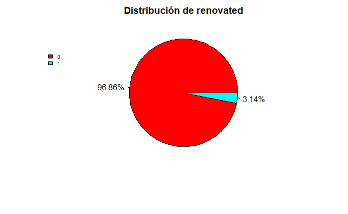

```r
workclass_7 <- table(dataset$renovated)
lb = paste0(round(prop.table(workclass_7)*100,2),"%")
pie(workclass_7,labels = lb, col = rainbow(2),main="Distribución de renovated")
legend(-2.1,0.4,legend=names(workclass_7),cex=0.7,yjust=0.2, xjust = -0.1,
       fill = rainbow(2), bty = "n")
```

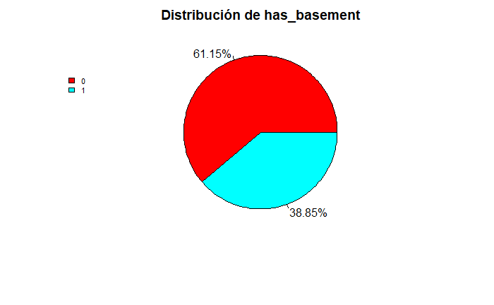

```r
workclass_8 <- table(dataset$has_basement)


lb = paste0(round(prop.table(workclass_8)*100,2),"%")
pie(workclass_8,labels = lb, col = rainbow(2),main="Distribución de has_basement")
legend(-2.1,0.4,legend=names(workclass_8),cex=0.7,yjust=0.2, xjust = -0.1,
       fill = rainbow(2), bty = "n")
```

### Grade y Condition

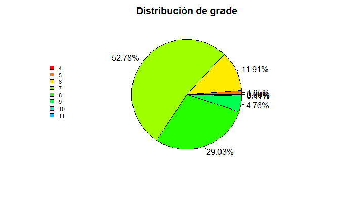

```r
workclass_9<- table(dataset$grade)

lb = paste0(round(prop.table(workclass_9)*100,2),"%")
pie(workclass_9,labels = lb, col = rainbow(13),main="Distribución de grade")
legend(-2.1,0.4,legend=names(workclass_9),cex=0.7,yjust=0.9, xjust = -0.1,
       fill = rainbow(13), bty = "n")
```

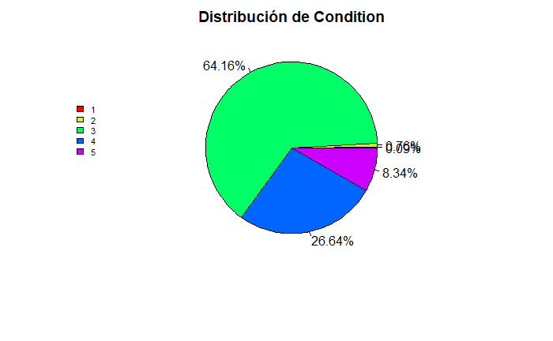

```r
workclass_10<- table(dataset$condition)

lb = paste0(round(prop.table(workclass_10)*100,2),"%")
pie(workclass_10,labels = lb, col = rainbow(5),main="Distribución de Condition")
legend(-2.1,0.4,legend=names(workclass_10),cex=0.7,yjust=0.9, xjust = -0.1,
       fill = rainbow(5), bty = "n")
```

### View y Waterfront

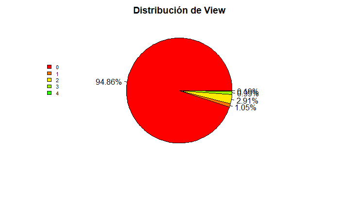

```r
workclass_11<- table(dataset$view)

lb = paste0(round(prop.table(workclass_11)*100,2),"%")
pie(workclass_11,labels = lb, col = rainbow(13),main="Distribución de View")
legend(-2.1,0.4,legend=names(workclass_11),cex=0.7,yjust=0.9, xjust = -0.1,
       fill = rainbow(13), bty = "n")
```

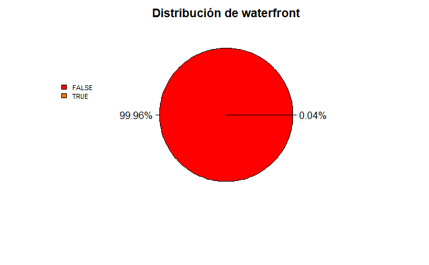

```r
workclass_12<- table(dataset$waterfront)

lb = paste0(round(prop.table(workclass_12)*100,2),"%")
pie(workclass_12,labels = lb, col = rainbow(13),main="Distribución de waterfront")
legend(-2.1,0.4,legend=names(workclass_12),cex=0.7,yjust=0.9, xjust = -0.1,
       fill = rainbow(13), bty = "n")
```

## Histogramas

### Price

```r
hist(dataset$price/1000,main="Histograma de Price",xlab="Price [1 = U$D 1000]",freq=F,col="gray",breaks=10)

x<-as.factor(dataset$price/1000)

lines(density(dataset$price/1000),col="red",lwd=2)
```

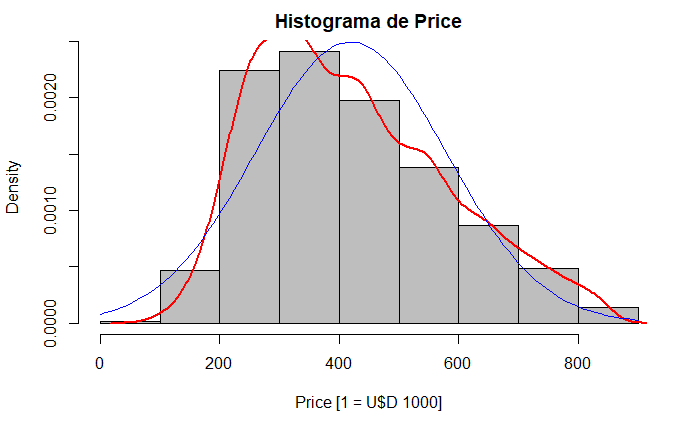

```r
curve(dnorm(x,mean=mean(dataset$price/1000),sd=sd(dataset$price/1000)),
      add=TRUE,
      col = "blue")
```

### Sqft_living

```r
hist(dataset$sqft_living,main="Histograma de sqft_living",xlab="sqft_living",freq=F,col="gray",breaks=10)

x<-as.factor(dataset$sqft_living)

lines(density(dataset$sqft_living),col="red",lwd=2)
```

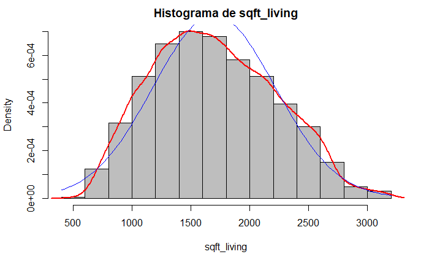

```r
curve(dnorm(x,mean=mean(dataset$sqft_living),sd=sd(dataset$sqft_living)),
      add=TRUE,
      col = "blue")
```

### Sqft_lot

```r
hist(dataset$sqft_lot/1000,main="Histograma de sqft_lot",xlab="sqft_lot [1 = 1000 sqft]",freq=F,col="gray",breaks=10)

x<-as.factor(dataset$sqft_lot/1000)

lines(density(dataset$sqft_lot/1000),col="red",lwd=2)
```

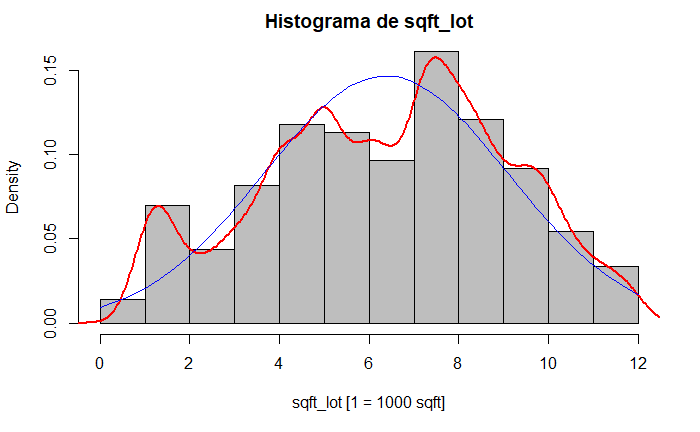

```r
curve(dnorm(x,mean=mean(dataset$sqft_lot/1000),sd=sd(dataset$sqft_lot/1000)),
      add=TRUE,
      col = "blue")
```

### Sqft_living15

```r
hist(dataset$sqft_living15,main="Histograma de sqft_living15",xlab="sqft_living15",freq=F,col="gray",breaks=10)

x<-as.factor(dataset$sqft_living15)

lines(density(dataset$sqft_living15),col="red",lwd=2)
```

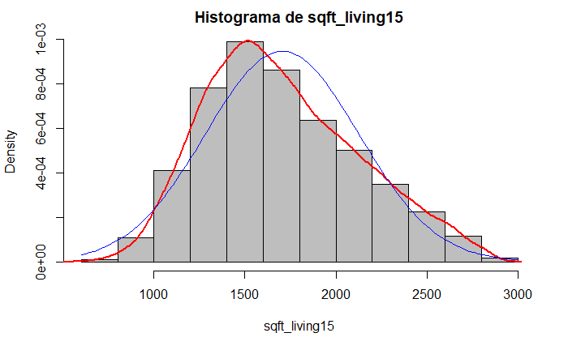

```r
curve(dnorm(x,mean=mean(dataset$sqft_living15),sd=sd(dataset$sqft_living15)),
      add=TRUE,
      col = "blue")
```

### Sqft_lot15

```r
hist(dataset$sqft_lot15/1000,main="Histograma de sqft_lot15",xlab="sqft_lot15 [1 = 1000 sqft]",freq=F,col="gray",breaks=10)

x<-as.factor(dataset$sqft_lot15/1000)

lines(density(dataset$sqft_lot15/1000),col="red",lwd=2)
```

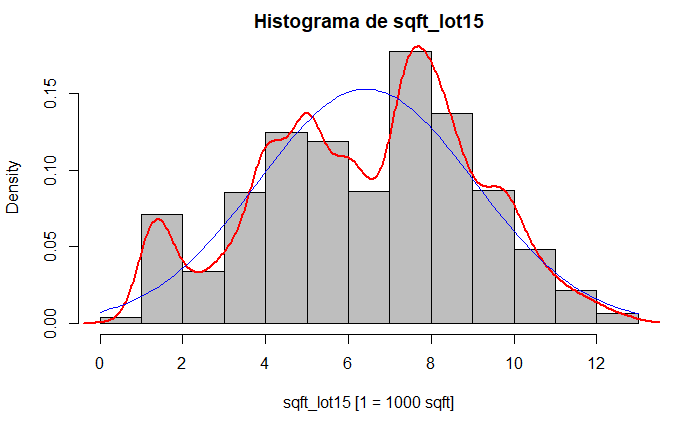

```r
curve(dnorm(x,mean=mean(dataset$sqft_lot15/1000),sd=sd(dataset$sqft_lot15/1000)),
      add=TRUE,
      col = "blue")
```

## Distribuciones respecto a la variable objetivo

### Price vs Bathrooms

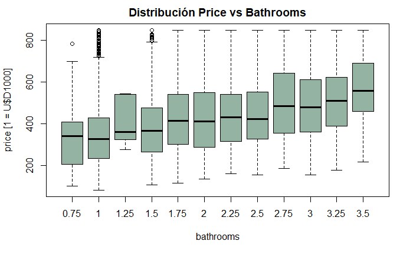

```r
boxplot(dataset$price/1000 ~ dataset$bathrooms , col=rgb(0.3,0.5,0.4,0.6) , ylab="price [1 = U$D1000]" ,
    xlab="bathrooms",main="Distribución Price vs Bathrooms")
```

### Price vs Bedrooms

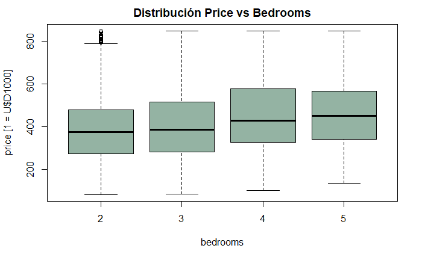

```r
boxplot(dataset$price/1000 ~ dataset$bedrooms , col=rgb(0.3,0.5,0.4,0.6) , ylab="price [1 = U$D1000]" ,
    xlab="bedrooms",main="Distribución Price vs Bedrooms")
```

### Price vs Sqft_living

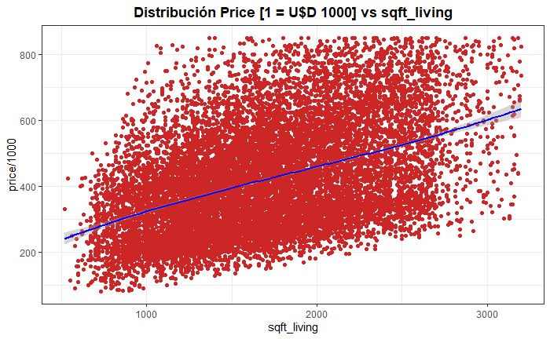

```r
ggplot(data=dataset,aes(x=sqft_living,y=price/1000))+
  geom_point(colour=c("firebrick3"))+
  stat_smooth(method="lm",formula=y~poly(x,3),color="blue")+
theme_bw()+labs(title="Distribución Price [1 = U$D 1000] vs sqft_living")+
  theme(plot.title=element_text(hjust=0.5,face="bold"))
```

### Price vs Sqft_living15

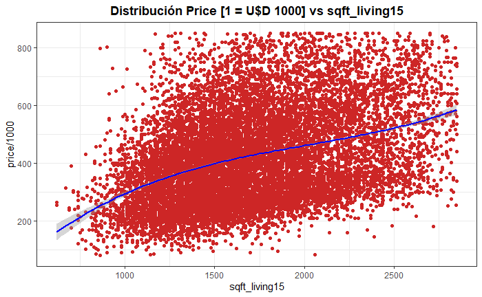

```r
ggplot(data=dataset,aes(x=sqft_living15,y=price/1000))+
  geom_point(colour=c("firebrick3"))+
  stat_smooth(method="lm",formula=y~poly(x,3),color="blue")+
theme_bw()+labs(title="Distribución Price [1 = U$D 1000] vs sqft_living15")+
  theme(plot.title=element_text(hjust=0.5,face="bold"))
```

### Price vs Sqft_lot

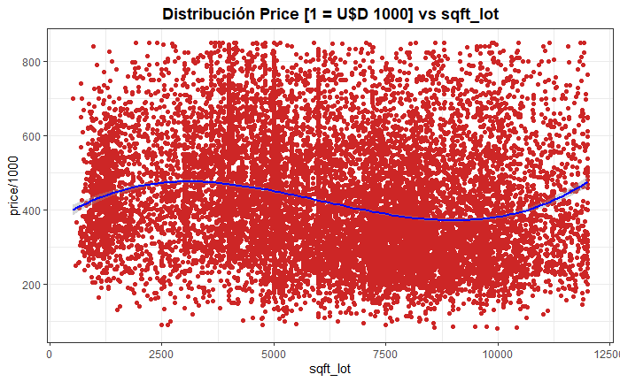

```r
ggplot(data=dataset,aes(x=sqft_lot,y=price/1000))+
  geom_point(colour=c("firebrick3"))+
  stat_smooth(method="lm",formula=y~poly(x,3),color="blue")+
theme_bw()+labs(title="Distribución Price [1 = U$D 1000] vs sqft_lot")+
  theme(plot.title=element_text(hjust=0.5,face="bold"))
```

### Price vs Sqft_lot15

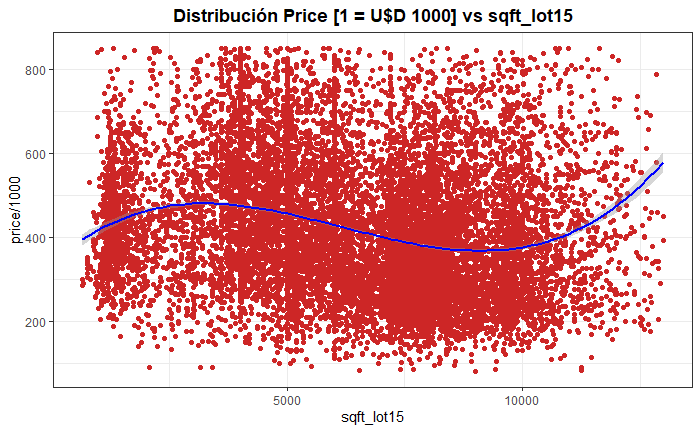

```r
ggplot(data=dataset,aes(x=sqft_lot15,y=price/1000))+
  geom_point(colour=c("firebrick3"))+
  stat_smooth(method="lm",formula=y~poly(x,3),color="blue")+
theme_bw()+labs(title="Distribución Price [1 = U$D 1000] vs sqft_lot15")+
  theme(plot.title=element_text(hjust=0.5,face="bold"))
```

### Price vs Grade

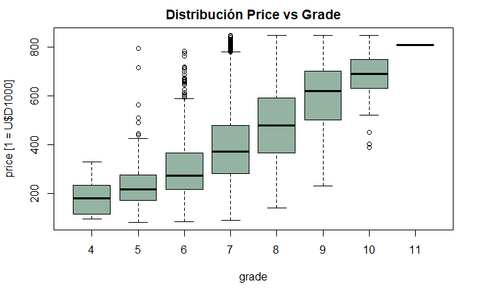

```r
boxplot(dataset$price/1000 ~dataset$grade , col=rgb(0.3,0.5,0.4,0.6) , ylab="price [1 = U$D1000]" ,
    xlab="grade",main="Distribución Price vs Grade")
```

### Price vs View

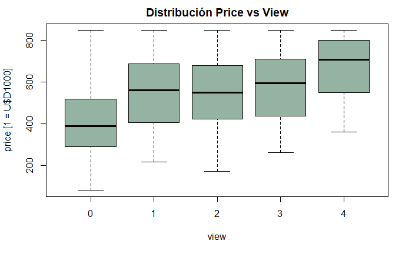

```r
boxplot(dataset$price/1000 ~ dataset$view , col=rgb(0.3,0.5,0.4,0.6) , ylab="price [1 = U$D1000]" ,
    xlab="view",main="Distribución Price vs View")
```

### Price vs Waterfront

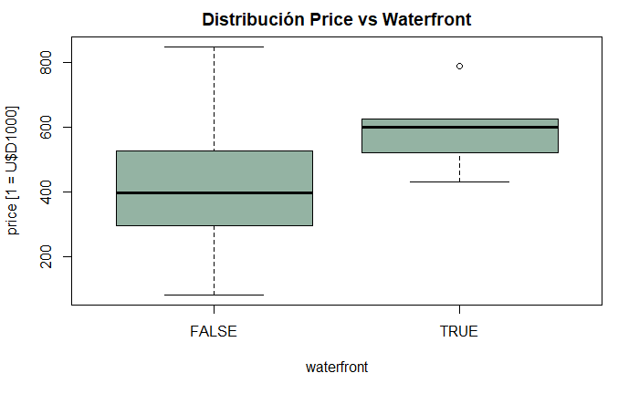

```r
boxplot(dataset$price/1000 ~ dataset$waterfront , col=rgb(0.3,0.5,0.4,0.6) , ylab="price [1 = U$D1000]" ,
    xlab="waterfront",main="Distribución Price vs Waterfront")
```

### Price vs Renovated

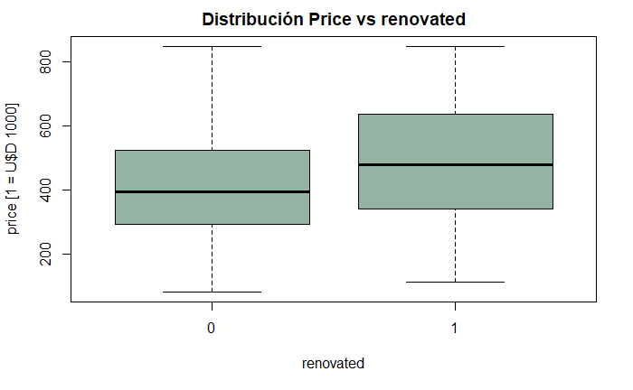

```r
boxplot(dataset$price/1000 ~ dataset$renovated , col=rgb(0.3,0.5,0.4,0.6) , ylab="price [1 = U$D 1000]" ,
    xlab="renovated",main="Distribución Price vs renovated")
```

### Price vs Has_basement

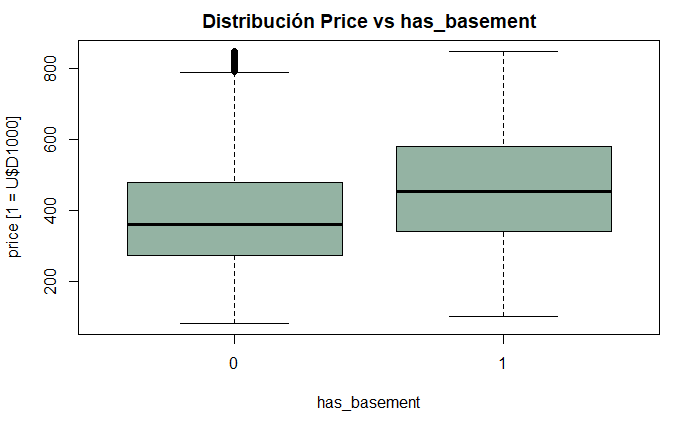

```r
boxplot(dataset$price/1000 ~ dataset$has_basement , col=rgb(0.3,0.5,0.4,0.6) , ylab="price [1 = U$D1000]" ,
    xlab="has_basement",main="Distribución Price vs has_basement")
```

### Price vs Sqft_above

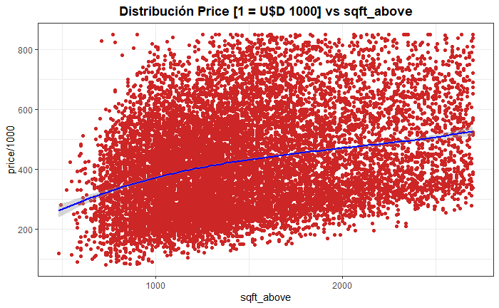

```r
ggplot(data=dataset,aes(x=sqft_above,y=price/1000))+
  geom_point(colour=c("firebrick3"))+
  stat_smooth(method="lm",formula=y~poly(x,3),color="blue")+
theme_bw()+labs(title="Distribución Price [1 = U$D 1000] vs sqft_above")+
  theme(plot.title=element_text(hjust=0.5,face="bold"))
```

## Interpretación

Se puede observar que en el boxplot de Price ya no se observan valores fuera de los límites. La mediana situada en el centro nos da indicio de que su distribución es un tanto simétrica. El 50% de los valores están entre 294000 y 529130 El histograma de Price nos muestra que la densidad y la distribución coinciden un tanto. Se puede observar que hay una distribución tendiente a ser simétrica, los datos no están tan dispersos como lo estaban en el dataset crudo.

En cuanto al boxplot de bedrooms, tampoco observamos valores atípicos. La mediana se encuentra en la parte inferior por lo que podemos decir que tiene una asimetría segada a la derecha. El 50% de los valores están entre 3 y 4. En la distribución Price con bedrooms hay un ligero aumento en el precio en casas que poseen más de 4 baños. Esto se da en casas de hasta 297000 dólares.

El histograma de sqft_living nos muestra que la densidad y la distribución coinciden un tanto. Se puede observar que hay una distribución tendiente a ser simétrica, los datos no están tan dispersos como lo estaban en el dataset crudo. En la distribución de Price con sqft_living se puede observar que a mayor sqft mayor es el precio. Podemos decir que hay una tendencia un tanto creciente.

En la distribución de Price con sqft_living15 se puede observar una tendencia levemente creciente. El histograma de sqft_living15 nos muestra que la densidad y la distribución coinciden un tanto. Se puede observar que hay una distribución tendiente a ser simétrica, los datos no están tan dispersos como lo estaban en el dataset crudo.

En el boxplot, Living y living15 tampoco tienen valores fuera de los límites. Podemos decir que ambos tienen una distribución un tanto simétrica. El 50% de los valores en living van de 1300 a 2080 y en living 15 de 1390 a 1990.

El histograma de sqft_lot nos muestra que la densidad y la distribución coinciden un tanto. Se puede observar que hay una distribución tendiente a ser simétrica, los datos no están tan dispersos como lo estaban en el dataset crudo. El histograma de sqft_lot15 nos muestra que la densidad y la distribución coinciden un tanto. Se puede observar que hay una distribución tendiente a ser simétrica, los datos no están tan dispersos como lo estaban en el dataset crudo. En cuanto a sqft_lot y sqft_lot15, no se observan valores atípicos en los gráficos. El 50% de los datos del primero están entre 4400 y 8400 y el 50% de los datos del segundo están entre 4520 y 8293. Ambos tienen una distribución un tanto simétrica. En la distribución de Price con sqft_lot ni sqft_lot15 no se observa tendencia alguna.

El pie plot de renovated nos indica que mas del 96% de las casas no fueron renovadas.

El pie plot de has_basement nos dice que mas del 60% de las casas no tienen sótano.

El pie plot de waterfront nos dice que casi el 100% de las casas no tiene una vista al lago. En la distribución de Price con waterfront se observa que la mayoría de las casas no poseen vista al lago pero que sin embargo las casas que si poseen una vista al lago son costosas.

En el boxplot de bathrooms tampoco se observan valores atípicos. Tiene también una distribución un tanto simétrica. El 50% de los datos está entre 1.5 y 2.5 En la distribución Price con bathrooms podemos ver un leve aumento en el precio de las casas que poseen mayor cantidad de baños. Esto se da en casas menores a 590000 dólares.

El boxplot de floors no cuenta con valores fuera de los límites. Tiene una distribución segada a la derecha se podría decir y el 50% de los datos se encuentran entre 1 y 2.

# Matriz de Correlación

## Matriz de correlación con variable objetivo(Dataset Limpio)

```r
clean_data_with_price <- dataset
clean_data_with_price$date = NULL
data_correlation_with_price_clean<- cor(clean_data_with_price)
data_correlation_with_price_clean
```

```
                    price     bedrooms    bathrooms sqft_living     sqft_lot
price          1.00000000  0.160780155  0.292279579  0.44108796 -0.166342305
bedrooms       0.16078015  1.000000000  0.410707820  0.59531139  0.233455897
bathrooms      0.29227958  0.410707820  1.000000000  0.65402310 -0.130994152
sqft_living    0.44108796  0.595311386  0.654023098  1.00000000  0.161598346
sqft_lot      -0.16634230  0.233455897 -0.130994152  0.16159835  1.000000000
floors         0.17233596  0.067175441  0.495427020  0.22163074 -0.498189137
waterfront     0.02063016 -0.004395473 -0.006192404  0.01070773  0.015586463
view           0.19536484  0.012266078  0.042893217  0.11847657  0.007171804
condition      0.09210279  0.054046910 -0.130642685 -0.01488260  0.166204902
grade          0.47273000  0.216386121  0.548893808  0.53856161 -0.103660962
sqft_above     0.28901346  0.428246948  0.571474424  0.74140519  0.104899774
yr_built      -0.09914858  0.108957118  0.564762954  0.26267245 -0.129183821
zipcode        0.07811665 -0.160405557 -0.223264376 -0.18458792 -0.245382126
lat            0.52801006 -0.097922452 -0.063701135 -0.03883314 -0.186283171
long          -0.07232903  0.128639174  0.232352608  0.20203098  0.226666520
sqft_living15  0.37491033  0.351749990  0.469263341  0.65378719  0.199792119
sqft_lot15    -0.17963549  0.214358555 -0.131430488  0.13796028  0.900699586
renovated      0.08481973  0.009135824  0.010254808  0.02369017 -0.013639024
has_basement   0.24148557  0.162588458  0.156577430  0.29424453 -0.031925149
                    floors   waterfront         view    condition        grade
price          0.172335964  0.020630156  0.195364837  0.092102787  0.472730003
bedrooms       0.067175441 -0.004395473  0.012266078  0.054046910  0.216386121
bathrooms      0.495427020 -0.006192404  0.042893217 -0.130642685  0.548893808
sqft_living    0.221630737  0.010707725  0.118476570 -0.014882596  0.538561615
sqft_lot      -0.498189137  0.015586463  0.007171804  0.166204902 -0.103660962
floors         1.000000000 -0.008075292 -0.030216717 -0.273558015  0.432664325
waterfront    -0.008075292  1.000000000  0.152638950  0.016658043 -0.006188714
view          -0.030216717  0.152638950  1.000000000  0.020079388  0.082915524
condition     -0.273558015  0.016658043  0.020079388  1.000000000 -0.171707752
grade          0.432664325 -0.006188714  0.082915524 -0.171707752  1.000000000
sqft_above     0.489787112  0.002268878  0.015865861 -0.153557534  0.551908846
yr_built       0.518316316 -0.020539005 -0.086663888 -0.349915094  0.478689117
zipcode       -0.048914755  0.020192243  0.126274125 -0.013111144 -0.156227067
lat            0.017624690 -0.023322221  0.013558215  0.005361652  0.071249218
long           0.093426458 -0.018030840 -0.098339121 -0.070387276  0.134376935
sqft_living15  0.161573767  0.005561717  0.161297884 -0.092514649  0.518344124
sqft_lot15    -0.484485470  0.018148324  0.008262059  0.161284868 -0.098502831
renovated     -0.009610710  0.040163045  0.042616694 -0.058734714 -0.018157124
has_basement  -0.269255469  0.008240378  0.128334662  0.105553099  0.055240960
```

[output cut: 25 more lines]

```
sqft_lot        0.199792119  0.900699586 -0.013639024 -0.031925149
floors          0.161573767 -0.484485470 -0.009610710 -0.269255469
waterfront      0.005561717  0.018148324  0.040163045  0.008240378
view            0.161297884  0.008262059  0.042616694  0.128334662
condition      -0.092514649  0.161284868 -0.058734714  0.105553099
grade           0.518344124 -0.098502831 -0.018157124  0.055240960
sqft_above      0.606901545  0.082943431  0.002119368 -0.319832668
yr_built        0.285926156 -0.107253694 -0.195406653 -0.140561606
zipcode        -0.263892174 -0.228787308  0.065361399  0.168403637
lat            -0.036695416 -0.178626981  0.023654530  0.150972175
long            0.295841902  0.220243075 -0.055030819 -0.242463697
sqft_living15   1.000000000  0.209968510 -0.044486257  0.065128900
sqft_lot15      0.209968510  1.000000000 -0.009149595 -0.029393416
renovated      -0.044486257 -0.009149595  1.000000000  0.011873724
has_basement    0.065128900 -0.029393416  0.011873724  1.000000000
```

[figure not shown]

```r
corrplot(data_correlation_with_price,method="square")
```

## Matriz de correlación sin variable objetivo(Dataset Limpio)

Luego, procedemos a elaborar otra matriz de correlación sin la variable objetivo. Para poder tomar conocimiento de como se relacionan las predictoras entre ellas.

Las variables “predictoras” pueden perjudicar la confiabilidad del modelo, sobre todo si estan correlacionadas. - bathrooms: tiene alta correlación con sqft_living,grade,sqft_above y sqft_living15. - sqft_living: tiene alta correlación con bathrooms,grade,sqft_above y sqft_living15. - sqft_above: tiene alta correlación con bathrooms,grade,sqft_above y sqft_living15. - sqtf_living15: tiene alta correlación con bathrooms,grade,sqft_above y sqft_living. Al tener una alta correlación entre las variables predictoras podemos tener potenciales colinealidades. Entonces vamos a aplicar las técnicas de selección de variables mas confiables como Ridge y Lasso.

```r
clean_data_without_price <- dataset
clean_data_without_price$date = NULL
clean_data_without_price$price = NULL
clean_data_correlation_without_price<- cor(clean_data_without_price)
clean_data_correlation_without_price
```

```
                  bedrooms    bathrooms sqft_living     sqft_lot       floors
bedrooms       1.000000000  0.410707820  0.59531139  0.233455897  0.067175441
bathrooms      0.410707820  1.000000000  0.65402310 -0.130994152  0.495427020
sqft_living    0.595311386  0.654023098  1.00000000  0.161598346  0.221630737
sqft_lot       0.233455897 -0.130994152  0.16159835  1.000000000 -0.498189137
floors         0.067175441  0.495427020  0.22163074 -0.498189137  1.000000000
waterfront    -0.004395473 -0.006192404  0.01070773  0.015586463 -0.008075292
view           0.012266078  0.042893217  0.11847657  0.007171804 -0.030216717
condition      0.054046910 -0.130642685 -0.01488260  0.166204902 -0.273558015
grade          0.216386121  0.548893808  0.53856161 -0.103660962  0.432664325
sqft_above     0.428246948  0.571474424  0.74140519  0.104899774  0.489787112
yr_built       0.108957118  0.564762954  0.26267245 -0.129183821  0.518316316
zipcode       -0.160405557 -0.223264376 -0.18458792 -0.245382126 -0.048914755
lat           -0.097922452 -0.063701135 -0.03883314 -0.186283171  0.017624690
long           0.128639174  0.232352608  0.20203098  0.226666520  0.093426458
sqft_living15  0.351749990  0.469263341  0.65378719  0.199792119  0.161573767
sqft_lot15     0.214358555 -0.131430488  0.13796028  0.900699586 -0.484485470
renovated      0.009135824  0.010254808  0.02369017 -0.013639024 -0.009610710
has_basement   0.162588458  0.156577430  0.29424453 -0.031925149 -0.269255469
                waterfront         view    condition        grade   sqft_above
bedrooms      -0.004395473  0.012266078  0.054046910  0.216386121  0.428246948
bathrooms     -0.006192404  0.042893217 -0.130642685  0.548893808  0.571474424
sqft_living    0.010707725  0.118476570 -0.014882596  0.538561615  0.741405192
sqft_lot       0.015586463  0.007171804  0.166204902 -0.103660962  0.104899774
floors        -0.008075292 -0.030216717 -0.273558015  0.432664325  0.489787112
waterfront     1.000000000  0.152638950  0.016658043 -0.006188714  0.002268878
view           0.152638950  1.000000000  0.020079388  0.082915524  0.015865861
condition      0.016658043  0.020079388  1.000000000 -0.171707752 -0.153557534
grade         -0.006188714  0.082915524 -0.171707752  1.000000000  0.551908846
sqft_above     0.002268878  0.015865861 -0.153557534  0.551908846  1.000000000
yr_built      -0.020539005 -0.086663888 -0.349915094  0.478689117  0.420054282
zipcode        0.020192243  0.126274125 -0.013111144 -0.156227067 -0.294236842
lat           -0.023322221  0.013558215  0.005361652  0.071249218 -0.135334755
long          -0.018030840 -0.098339121 -0.070387276  0.134376935  0.362784670
sqft_living15  0.005561717  0.161297884 -0.092514649  0.518344124  0.606901545
sqft_lot15     0.018148324  0.008262059  0.161284868 -0.098502831  0.082943431
renovated      0.040163045  0.042616694 -0.058734714 -0.018157124  0.002119368
has_basement   0.008240378  0.128334662  0.105553099  0.055240960 -0.319832668
                 yr_built     zipcode          lat        long sqft_living15
bedrooms       0.10895712 -0.16040556 -0.097922452  0.12863917   0.351749990
```

[output cut: 21 more lines]

```
sqft_lot       0.900699586 -0.013639024 -0.031925149
floors        -0.484485470 -0.009610710 -0.269255469
waterfront     0.018148324  0.040163045  0.008240378
view           0.008262059  0.042616694  0.128334662
condition      0.161284868 -0.058734714  0.105553099
grade         -0.098502831 -0.018157124  0.055240960
sqft_above     0.082943431  0.002119368 -0.319832668
yr_built      -0.107253694 -0.195406653 -0.140561606
zipcode       -0.228787308  0.065361399  0.168403637
lat           -0.178626981  0.023654530  0.150972175
long           0.220243075 -0.055030819 -0.242463697
sqft_living15  0.209968510 -0.044486257  0.065128900
sqft_lot15     1.000000000 -0.009149595 -0.029393416
renovated     -0.009149595  1.000000000  0.011873724
has_basement  -0.029393416  0.011873724  1.000000000
```

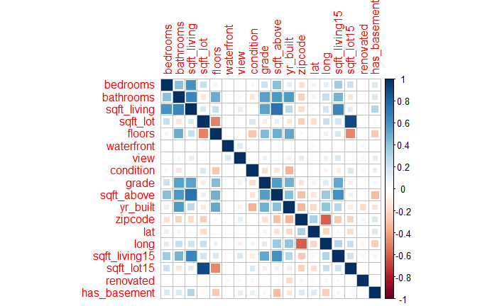

```r
corrplot(clean_data_correlation_without_price,method="square")
```

# **Selección de Modelos y Regularización**

## Best Subset Selection

```r
regsubset.full <- regsubsets(price ~ ., data = dataset)
```

### Sumario de regsubset

```r
sumario.regsubset <- summary(regsubset.full)
sumario.regsubset
```

```
Subset selection object
Call: regsubsets.formula(price ~ ., data = dataset)
19 Variables  (and intercept)
               Forced in Forced out
date               FALSE      FALSE
bedrooms           FALSE      FALSE
bathrooms          FALSE      FALSE
sqft_living        FALSE      FALSE
sqft_lot           FALSE      FALSE
floors             FALSE      FALSE
waterfrontTRUE     FALSE      FALSE
view               FALSE      FALSE
condition          FALSE      FALSE
grade              FALSE      FALSE
sqft_above         FALSE      FALSE
yr_built           FALSE      FALSE
zipcode            FALSE      FALSE
lat                FALSE      FALSE
long               FALSE      FALSE
sqft_living15      FALSE      FALSE
sqft_lot15         FALSE      FALSE
renovated          FALSE      FALSE
has_basement       FALSE      FALSE
1 subsets of each size up to 8
Selection Algorithm: exhaustive
         date bedrooms bathrooms sqft_living sqft_lot floors waterfrontTRUE view
1  ( 1 ) " "  " "      " "       " "         " "      " "    " "            " "
2  ( 1 ) " "  " "      " "       "*"         " "      " "    " "            " "
3  ( 1 ) " "  " "      " "       "*"         " "      " "    " "            " "
4  ( 1 ) " "  " "      " "       "*"         " "      " "    " "            " "
5  ( 1 ) " "  " "      " "       "*"         " "      " "    " "            " "
6  ( 1 ) " "  " "      " "       "*"         " "      " "    " "            " "
7  ( 1 ) " "  " "      " "       "*"         " "      " "    " "            " "
8  ( 1 ) " "  " "      " "       "*"         " "      " "    " "            "*"
         condition grade sqft_above yr_built zipcode lat long sqft_living15
1  ( 1 ) " "       " "   " "        " "      " "     "*" " "  " "
2  ( 1 ) " "       " "   " "        " "      " "     "*" " "  " "
3  ( 1 ) " "       "*"   " "        " "      " "     "*" " "  " "
4  ( 1 ) " "       "*"   " "        "*"      " "     "*" " "  " "
5  ( 1 ) " "       "*"   " "        "*"      " "     "*" " "  " "
6  ( 1 ) " "       "*"   " "        "*"      " "     "*" " "  "*"
7  ( 1 ) "*"       "*"   " "        "*"      " "     "*" " "  "*"
8  ( 1 ) "*"       "*"   " "        "*"      " "     "*" " "  "*"
         sqft_lot15 renovated has_basement
1  ( 1 ) " "        " "       " "
2  ( 1 ) " "        " "       " "
3  ( 1 ) " "        " "       " "
4  ( 1 ) " "        " "       " "
5  ( 1 ) "*"        " "       " "
6  ( 1 ) "*"        " "       " "
7  ( 1 ) "*"        " "       " "
8  ( 1 ) "*"        " "       " "
```

## Stepwise Selection

El estadístico Cp compara la precision y el sesgo del modelo completo con modelos que incluyan un subconjunto de predictores. Cp, AIC, BIC y R^2 ajustado son tecnicas que ajustan el error de entrenamiento para el tamaño del modelo y pueden ser usados para seleccionar entre un conjunto de modelos con diferentes numeros de variables.

### Cp

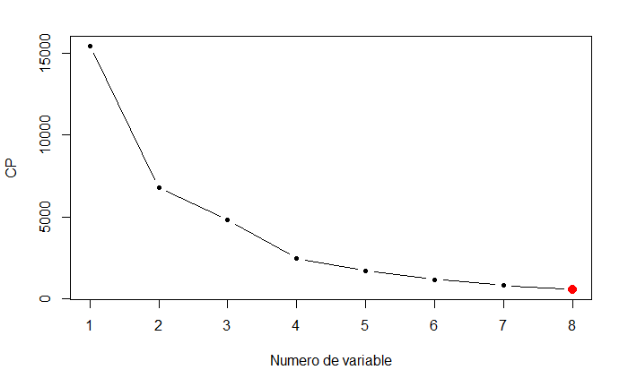

```r
plot(sumario.regsubset$cp,xlab = "Numero de variable",ylab="CP",pch = 20, type="b")
value.min <- which.min(sumario.regsubset$cp)

points(value.min,sumario.regsubset$cp[value.min],col = "red",cex = 2,pch = 20)
```

#### Ploteo de CP

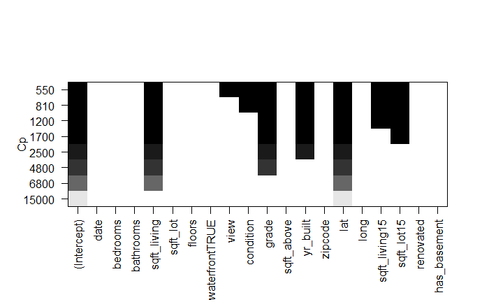

```r
plot(regsubset.full,scale="Cp")
```

### Coeficiente de Determinacion R^2

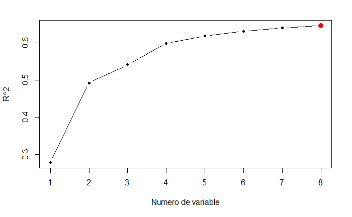

```r
plot(sumario.regsubset$rsq,xlab = "Numero de variable",ylab="R^2",pch = 20, type="b")
value.max <- which.max(sumario.regsubset$rsq)

points(value.min,sumario.regsubset$rsq[value.max],col = "red",cex = 2,pch = 20)
```

#### Ploteo de R^2

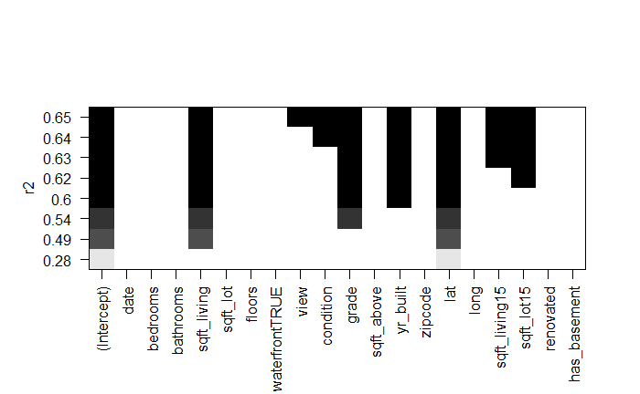

```r
plot(regsubset.full,scale="r2")
```

### Residual Sum Square (RSS)

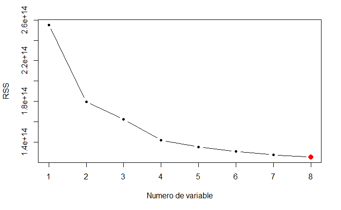

```r
plot(sumario.regsubset$rss,xlab = "Numero de variable",ylab="RSS",pch = 20, type="b")
value.min <- which.min(sumario.regsubset$rss)

points(value.min,sumario.regsubset$rss[value.min],col = "red",cex = 2,pch = 20)
```

### Bayesian Information Criterion(BIC)

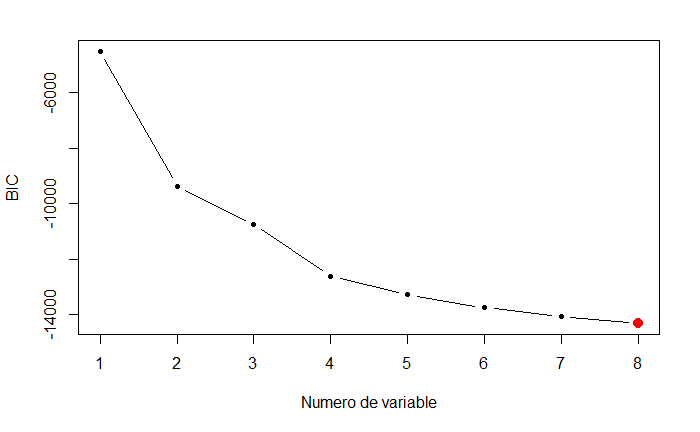

```r
plot(sumario.regsubset$bic,xlab = "Numero de variable",ylab="BIC",pch = 20, type="b")
value.min <- which.min(sumario.regsubset$bic)

points(value.min,sumario.regsubset$bic[value.min],col = "red",cex = 2,pch = 20)
```

#### Ploteo de BIC

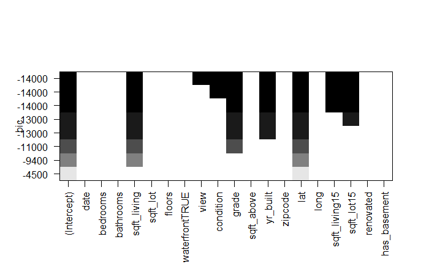

```r
plot(regsubset.full,scale="bic")
```

### R^2 Ajustado

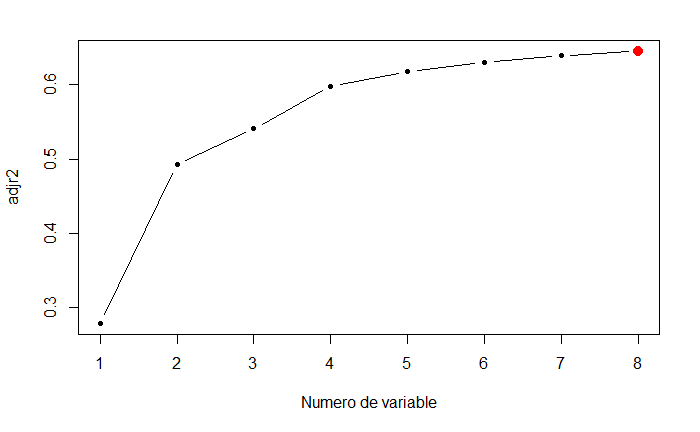

```r
plot(sumario.regsubset$adjr2,xlab = "Numero de variable",ylab="adjr2",pch = 20, type="b")
value.max <- which.max(sumario.regsubset$adjr2)

points(value.min,sumario.regsubset$adjr2[value.max],col = "red",cex = 2,pch = 20)
```

#### Ploteo de R^2 Ajustado

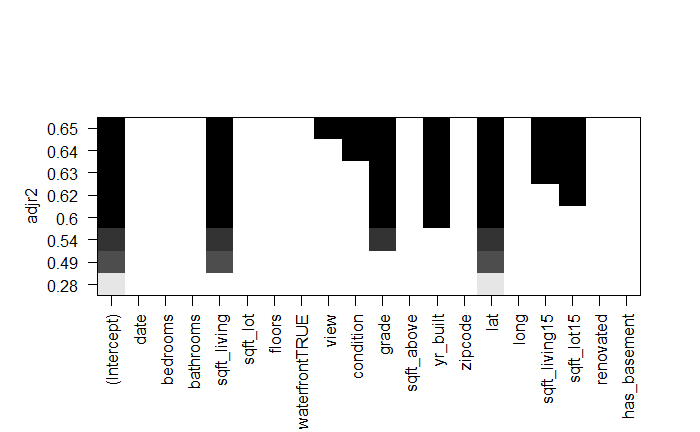

```r
plot(regsubset.full,scale="adjr2")
```

### Coeficientes

```r
coef(regsubset.full,8)
```

```
  (Intercept)   sqft_living          view     condition         grade      yr_built
-2.088217e+07  7.975791e+01  2.711295e+04  2.480757e+04  6.928484e+04 -1.408589e+03
          lat sqft_living15    sqft_lot15
 4.903414e+05  5.824681e+01 -1.117795e+01
```

### Conjunto de validación

Para el caso de estudio de House Price, se debera proceder a dividir las observaciones en dos: primero en entrenamiento (train, 70 %) y prueba (test, 30 %). Las proporciones pueden variar.

```r
index <- createDataPartition(dataset$price, p = 0.7, list = FALSE)
data.train <- dataset[index, ]
data.test <- dataset[-index, ]
```

Ejecutamos la instruccion regsubsets con los datos de entranamiento, a su vez, se busca que el numero máximo de parámetros sea 8 (nvmax) y el metodo forward. Posteriormente se muestra el sumario de los resultados.

```r
set.seed(10)
model.fwd <- regsubsets(price ~., data = data.train, nvmax = 8, method = "forward")
summary(model.fwd)
```

```
Subset selection object
Call: regsubsets.formula(price ~ ., data = data.train, nvmax = 8, method = "forward")
19 Variables  (and intercept)
               Forced in Forced out
date               FALSE      FALSE
bedrooms           FALSE      FALSE
bathrooms          FALSE      FALSE
sqft_living        FALSE      FALSE
sqft_lot           FALSE      FALSE
floors             FALSE      FALSE
waterfrontTRUE     FALSE      FALSE
view               FALSE      FALSE
condition          FALSE      FALSE
grade              FALSE      FALSE
sqft_above         FALSE      FALSE
yr_built           FALSE      FALSE
zipcode            FALSE      FALSE
lat                FALSE      FALSE
long               FALSE      FALSE
sqft_living15      FALSE      FALSE
sqft_lot15         FALSE      FALSE
renovated          FALSE      FALSE
has_basement       FALSE      FALSE
1 subsets of each size up to 8
Selection Algorithm: forward
         date bedrooms bathrooms sqft_living sqft_lot floors waterfrontTRUE view
1  ( 1 ) " "  " "      " "       " "         " "      " "    " "            " "
2  ( 1 ) " "  " "      " "       "*"         " "      " "    " "            " "
3  ( 1 ) " "  " "      " "       "*"         " "      " "    " "            " "
4  ( 1 ) " "  " "      " "       "*"         " "      " "    " "            " "
5  ( 1 ) " "  " "      " "       "*"         " "      " "    " "            " "
6  ( 1 ) " "  " "      " "       "*"         " "      " "    " "            " "
7  ( 1 ) " "  " "      " "       "*"         " "      " "    " "            " "
8  ( 1 ) " "  " "      " "       "*"         " "      " "    " "            "*"
         condition grade sqft_above yr_built zipcode lat long sqft_living15
1  ( 1 ) " "       " "   " "        " "      " "     "*" " "  " "
2  ( 1 ) " "       " "   " "        " "      " "     "*" " "  " "
3  ( 1 ) " "       "*"   " "        " "      " "     "*" " "  " "
4  ( 1 ) " "       "*"   " "        "*"      " "     "*" " "  " "
5  ( 1 ) " "       "*"   " "        "*"      " "     "*" " "  " "
6  ( 1 ) " "       "*"   " "        "*"      " "     "*" " "  "*"
7  ( 1 ) "*"       "*"   " "        "*"      " "     "*" " "  "*"
8  ( 1 ) "*"       "*"   " "        "*"      " "     "*" " "  "*"
         sqft_lot15 renovated has_basement
1  ( 1 ) " "        " "       " "
2  ( 1 ) " "        " "       " "
3  ( 1 ) " "        " "       " "
4  ( 1 ) " "        " "       " "
5  ( 1 ) "*"        " "       " "
6  ( 1 ) "*"        " "       " "
7  ( 1 ) "*"        " "       " "
8  ( 1 ) "*"        " "       " "
```

### Validación Cruzada

```r
set.seed(7)
folds <- sample(rep(1:8, length = nrow(dataset)))
folds
```

[output not shown]

```r
table(folds)
```

```
folds
   1    2    3    4    5    6    7    8
1734 1733 1733 1733 1733 1733 1733 1733
```

## Métodos de Contracción

### Ridge

```r
x.ridge <- model.matrix(price ~. , dataset)[,-1]
y.ridge <- dataset$price
```

```r
grid <- 10^seq(10,-2,length = 100)
ridge.model <- glmnet(x.ridge, y.ridge, alpha = 0, lambda = grid)
dim(coef(ridge.model))
```

```
[1]  20 100
```

#### Ploteo de Ridge

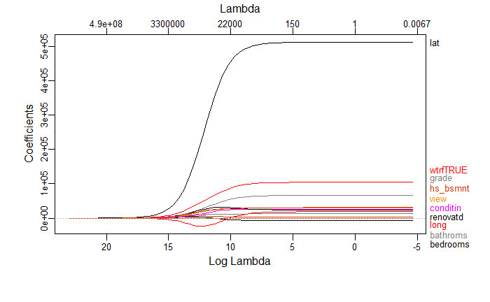

```r
plot_glmnet(ridge.model)
```

```r
predict(ridge.model, s = 8, type = "coefficients")
```

```
20 x 1 sparse Matrix of class "dgCMatrix"
                          s1
(Intercept)     2.477995e+06
date            7.874311e-04
bedrooms       -7.573455e+03
bathrooms       1.350159e+04
sqft_living     4.246647e+01
sqft_lot       -3.682007e+00
floors          2.279649e+03
waterfrontTRUE  1.039972e+05
view            2.940882e+04
condition       2.516517e+04
grade           6.590805e+04
sqft_above      4.606355e+01
yr_built       -1.682214e+03
zipcode        -2.310909e+02
lat             5.115484e+05
long            1.850302e+04
sqft_living15   4.916354e+01
sqft_lot15     -7.330496e+00
renovated       2.403811e+04
has_basement    3.079428e+04
```

#### Validación Cruzada

```r
set.seed(2)
indices <- sample(c(TRUE,FALSE), nrow(dataset), replace = TRUE)
y.test <- y.ridge[-indices]
```

```r
ridge.model.cv <- cv.glmnet(x.ridge[indices,], y.ridge[indices], alpha = 0) # Por defecto, 10-fold
coef(ridge.model.cv)
```

```
20 x 1 sparse Matrix of class "dgCMatrix"
                          s1
(Intercept)    -6.177230e+06
date            5.371984e-04
bedrooms       -4.539318e+03
bathrooms       9.969600e+03
sqft_living     4.749143e+01
sqft_lot       -4.264535e+00
floors          3.362743e+03
waterfrontTRUE  7.577320e+04
view            2.657520e+04
condition       2.492409e+04
grade           5.429152e+04
sqft_above      3.750897e+01
yr_built       -1.277632e+03
zipcode        -1.342878e+02
lat             4.526453e+05
long            5.426610e+03
sqft_living15   5.076519e+01
sqft_lot15     -6.132346e+00
renovated       3.148117e+04
has_basement    2.705608e+04
```

#### Ploteo del Modelo de Ridge

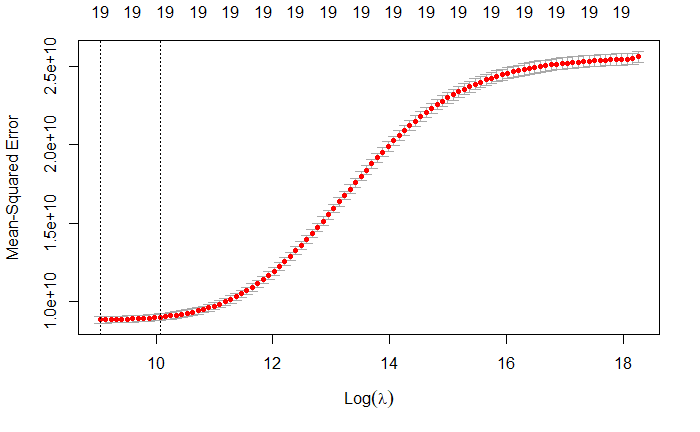

```r
plot(ridge.model.cv)
```

```r
bestlam <- ridge.model.cv$lambda.min
bestlam
```

```
[1] 8460.005
```

```r
ridge.pred <- predict(ridge.model, s = bestlam, newx = x.ridge[-indices,])
```

#### RMSE de Ridge

```r
rmse.ridge <- sqrt(mean((ridge.pred - y.test)^2))
rmse.ridge
```

```
[1] 93434.41
```

```r
out <- glmnet(x.ridge, y.ridge, alpha = 0)
predict(out, type = "coefficients", s = bestlam)
```

```
20 x 1 sparse Matrix of class "dgCMatrix"
                          s1
(Intercept)    -1.761183e+06
date            7.199662e-04
bedrooms       -6.301034e+03
bathrooms       1.183568e+04
sqft_living     4.617847e+01
sqft_lot       -3.934286e+00
floors          3.055272e+03
waterfrontTRUE  9.651457e+04
view            2.867710e+04
condition       2.505952e+04
grade           6.097148e+04
sqft_above      3.996863e+01
yr_built       -1.496870e+03
zipcode        -1.896385e+02
lat             4.892257e+05
long            1.033439e+04
sqft_living15   5.057892e+01
sqft_lot15     -6.705613e+00
renovated       2.773334e+04
has_basement    2.828264e+04
```

### Lasso

```r
x <- model.matrix(price ~ ., dataset)[,-1]
y <- dataset$price
```

#### Ploteo de Lasso

```r
install.packages("glmnet")
```

```
Error in install.packages : Updating loaded packages
```

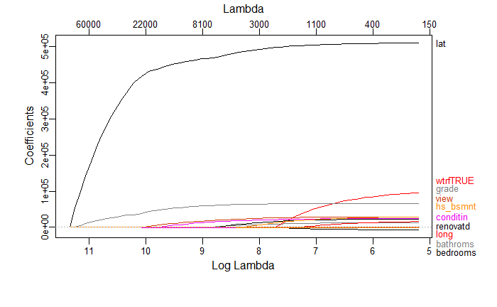

```r
library("glmnet")
lasso.model <- glmnet(x,y,alpha = 1)
plot_glmnet(lasso.model)
```

#### Validación Cruzada

```r
indices <- sample(c(TRUE,FALSE),nrow(dataset),replace=TRUE)
cv.out<- cv.glmnet(x[indices,],y[indices],alpha=1)
coef(cv.out)
```

```
20 x 1 sparse Matrix of class "dgCMatrix"
                          s1
(Intercept)    -1.238908e+07
date            3.976019e-04
bedrooms       -9.883116e+02
bathrooms       5.779572e+03
sqft_living     6.004560e+01
sqft_lot       -2.922639e+00
floors          .
waterfrontTRUE  2.873898e+04
view            2.564490e+04
condition       2.263052e+04
grade           6.355566e+04
sqft_above      2.190805e+01
yr_built       -1.377305e+03
zipcode        -9.308742e+01
lat             4.916269e+05
long            .
sqft_living15   4.778270e+01
sqft_lot15     -6.967204e+00
renovated       1.179000e+03
has_basement    1.298436e+04
```

#### Ploteo del Modelo de Lasso

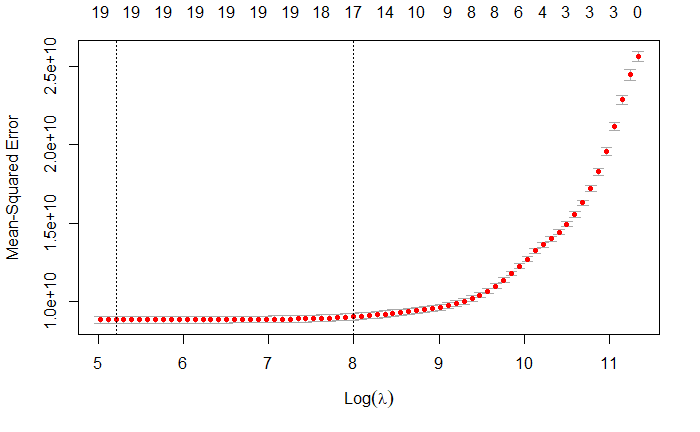

```r
plot(cv.out)
```

```r
bestlam <- cv.out$lambda.min
bestlam
```

```
[1] 181.5849
```

#### RMSE de Lasso

```r
lasso.pred <- predict(lasso.model,s=bestlam,newx=x[-indices,])
value_2 <- mean((lasso.pred-y[-indices])^2)
```

```r
rmse.lasso <- sqrt(value_2)
rmse.lasso
```

```
[1] 93233.55
```

# **Regresión Líneal**

La regresión lineal se usa para buscar relaciones significativa entre variables y predecir el valor de una variable dado el valor de otra. Los modelos con un predictor se denominan regresión simple. Los modelos con más de un predictor se conocen como regresión lineal múltiple.

## Dataset Crudo

```r
dataset.selection.raw <- raw_data_house[c("price","bathrooms","sqft_living","yr_built"
,"grade","waterfront","view","bedrooms")]
```

```r
mlr_raw <- lm(formula=price ~ ., data = dataset.selection.raw)
summary(mlr_raw)
```

```
Call:
lm(formula = price ~ ., data = dataset.selection.raw)

Residuals:
     Min       1Q   Median       3Q      Max
-1354189  -111550    -9308    90731  4269427

Coefficients:
                 Estimate Std. Error t value Pr(>|t|)
(Intercept)     6.464e+06  1.182e+05   54.68   <2e-16 ***
bathrooms       5.467e+04  3.315e+03   16.49   <2e-16 ***
sqft_living     1.651e+02  3.234e+00   51.05   <2e-16 ***
yr_built       -3.675e+03  6.230e+01  -58.99   <2e-16 ***
grade           1.271e+05  2.110e+03   60.25   <2e-16 ***
waterfrontTRUE  5.808e+05  1.868e+04   31.09   <2e-16 ***
view            4.446e+04  2.231e+03   19.93   <2e-16 ***
bedrooms       -3.765e+04  2.024e+03  -18.61   <2e-16 ***
---
Signif. codes:  0 ‘***’ 0.001 ‘**’ 0.01 ‘*’ 0.05 ‘.’ 0.1 ‘ ’ 1

Residual standard error: 217300 on 21605 degrees of freedom
Multiple R-squared:  0.6498,    Adjusted R-squared:  0.6497
F-statistic:  5728 on 7 and 21605 DF,  p-value: < 2.2e-16
```

Podemos ver en la parte superior de los resultados que hay una variación entre los valores máximos y mínimos y los cuartiles por lo que no hay una marcada simetría. En cuanto, a la significancia vemos que todos suman al modelo ya que t value es significativamente distinto de cero y todos tienen un código alto de significancia. El coeficiente de determinación R-Squared es bueno al igual que Adjusted R-Squared ya que tienen valores altos.

### Índice de Confianza

```r
confint(mlr_raw)
```

```
                      2.5 %       97.5 %
(Intercept)    6231838.9302 6695212.3839
bathrooms        48169.0934   61166.2657
sqft_living        158.7236     171.3996
yr_built         -3797.2349   -3552.9917
grade           122996.0933  131267.7562
waterfrontTRUE  544227.3380  617459.1214
view             40087.6311   48833.5898
bedrooms        -41619.4919  -33686.1509
```

### Validación del modelo

```r
stem(mlr_raw$residuals)
```

```
  The decimal point is 6 digit(s) to the right of the |

  -1 | 43221100000
  -0 | 99988888888888877777777777777777777777777766666666666666666666666666+113
  -0 | 44444444444444444444444444444444444444444444444444444444444444444444+11068
   0 | 00000000000000000000000000000000000000000000000000000000000000000000+9658
   0 | 55555555555555555555555555555555555555555555555555555555555555555555+325
   1 | 00000000000000000000011111111111111111222222222222222222233333333333+4
   1 | 55555555666667778999
   2 | 0001123
   2 | 58
   3 | 22
   3 | 9
   4 | 13
```

El histograma debe presentar caracterıstica de estar normalmente distribuido. Vemos que no la presenta. Hay que tener en cuenta que esto se realizó con el dataset crudo por lo que mas adelante haremos lo mismo pero con el dataset limpio. Decidimos agregar esta regresión ya que luego de probar con diferentes limpiezas, esta es la que mejor resultado nos arroja ya que el adjusted R-Squred es el mas alto que pudimos obtener y no queriamos descartarlo.

### Predecidos vs Actuales

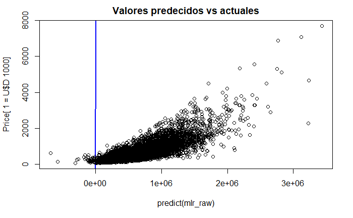

```r
plot(predict(mlr_raw),dataset.selection.raw$price/1000, ylab="Price[ 1 = U$D 1000]",
     main="Valores predecidos vs actuales",
abline(a=0,b=1,col="blue",lwd=2))
```

### Residuales

Podemos decir que en general es una buena gráfica, sin embargo, se pueden observar puntos alejados del resto los cuales pueden ser analizados y eliminados o modificados uno.

```r
plot(residuals(mlr_raw))
abline(a=0,b=0,col="blue",lwd=2)
```

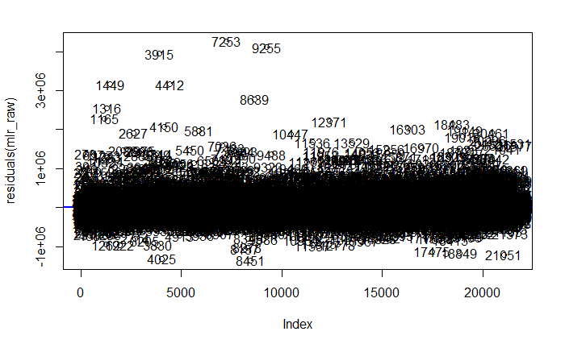

```r
text(residuals(mlr_raw))
```

### Ploteo del Modelo

En Scale-Location Plot el grafico muestra cómo se distribuyen los residuos y podemos ver que existe una varianza entre ellos que al comienzo es menor y que después se acrecenta

En Residuals vs Leverage Plot el plot ayuda a encontrar cuales son las observaciones influyentes. Aquı necesitamos verificar los puntos que estan fuera de la lınea discontinua. Un punto fuera de la lınea sera un punto influyente y su eliminación ́afectara los coeficientes de regresión. Se pueden observar varios puntos fuera de la línea.

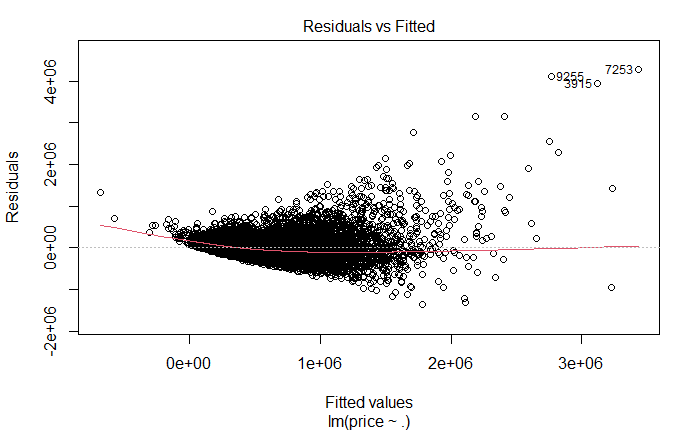

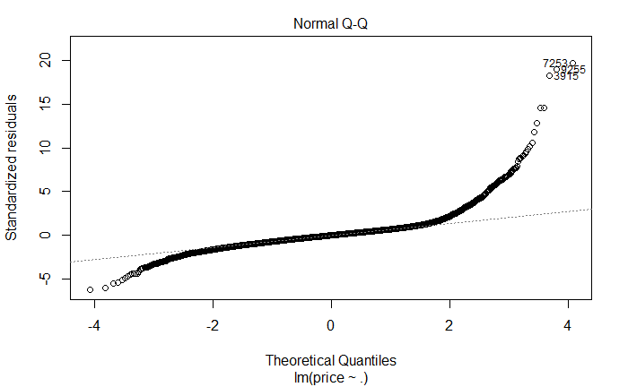

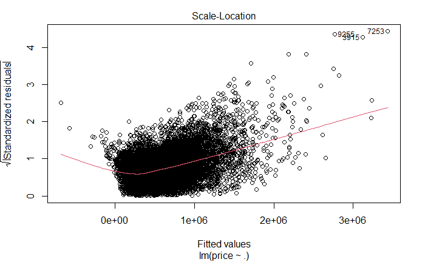

```r
plot(mlr_raw)
```

[figure not shown]

```r
install.packages("glmnet")
```

### Histograma de Residuales

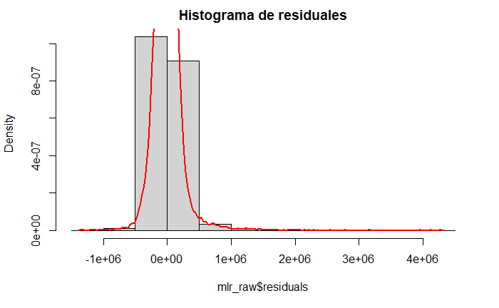

```r
hist(mlr_raw$residuals,main="Histograma de residuales",freq=F)
lines(density(mlr_raw$residuals),col = "red",lwd=2)
```

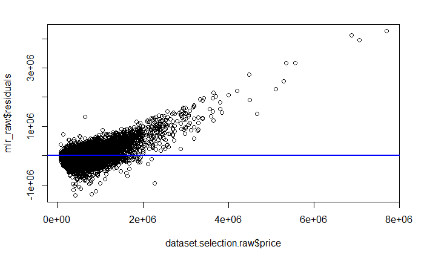

```r
plot(mlr_raw$residuals ~ dataset.selection.raw$price)
abline(a=0,b=0,col="blue",lwd=2)
```

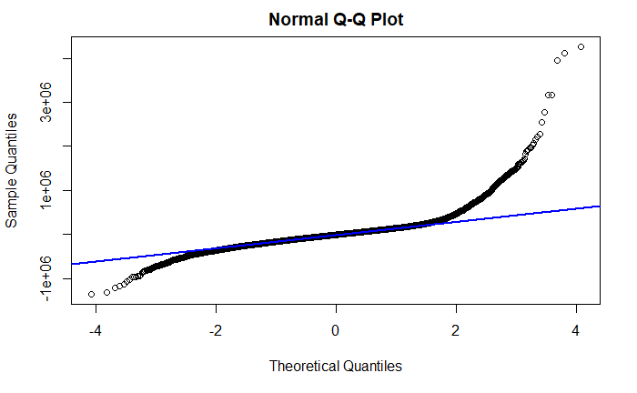

```r
qqnorm(mlr_raw$residuals)

qqline(mlr_raw$residuals,col="blue",lwd=2)
```

### Overfitting

```r
split_data_mlr <- createDataPartition(y =dataset.selection.raw$price,p=0.7,list=FALSE)

train_data_mlr <- dataset.selection.raw[split_data_mlr,]
test_data_mlr <- dataset.selection.raw[-split_data_mlr,]

lmfit1_mlr <- train( price ~ sqft_living+bathrooms+yr_built+
                   grade+waterfront+view+bedrooms, data = train_data_mlr,method="lm")

summary(lmfit1_mlr)
```

```
Call:
lm(formula = .outcome ~ ., data = dat)

Residuals:
     Min       1Q   Median       3Q      Max
-1436690  -110655    -8376    92831  4198087

Coefficients:
                 Estimate Std. Error t value Pr(>|t|)
(Intercept)     6.455e+06  1.450e+05   44.51   <2e-16 ***
sqft_living     1.784e+02  3.958e+00   45.09   <2e-16 ***
bathrooms       5.116e+04  4.053e+03   12.62   <2e-16 ***
yr_built       -3.656e+03  7.643e+01  -47.84   <2e-16 ***
grade           1.233e+05  2.586e+03   47.66   <2e-16 ***
waterfrontTRUE  6.497e+05  2.254e+04   28.82   <2e-16 ***
view            4.308e+04  2.688e+03   16.03   <2e-16 ***
bedrooms       -4.343e+04  2.561e+03  -16.95   <2e-16 ***
---
Signif. codes:  0 ‘***’ 0.001 ‘**’ 0.01 ‘*’ 0.05 ‘.’ 0.1 ‘ ’ 1

Residual standard error: 221100 on 15123 degrees of freedom
Multiple R-squared:  0.6528,    Adjusted R-squared:  0.6526
F-statistic:  4061 on 7 and 15123 DF,  p-value: < 2.2e-16
```

#### RMSE

El error cuadrático medio (RMSE) mide la cantidad de error que hay entre dos conjuntos de datos. En otras palabras, compara un valor predicho y un valor observado o conocido. Los valores más bajos de RMSE indican un mejor ajuste. RMSE es una buena medida de la precisión con que el modelo predice la respuesta, y es el criterio más importante para ajustar si el propósito principal del modelo es la predicción.

```r
predicted_test_mlr <- predict(lmfit1_mlr,test_data_mlr)
model_test_1_mlr <- data.frame(obs = test_data_mlr$price,pred=predicted_test_mlr)
defaultSummary(model_test_1_mlr)
```

```
        RMSE     Rsquared          MAE
2.087820e+05 6.417796e-01 1.404502e+05
```

#### Ploteo

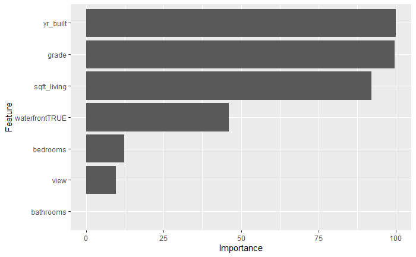

```r
ggplot(varImp(lmfit1_mlr))
```

### Cross Validation

```r
control1_mlr <- trainControl(method="cv",number=10)
lmfit2_mlr <- train(price ~. ,data = dataset.selection.raw,method="lm",trControl=control1_mlr,metric="Rsquared")
summary(lmfit2_mlr)
```

```
Call:
lm(formula = .outcome ~ ., data = dat)

Residuals:
     Min       1Q   Median       3Q      Max
-1354189  -111550    -9308    90731  4269427

Coefficients:
                 Estimate Std. Error t value Pr(>|t|)
(Intercept)     6.464e+06  1.182e+05   54.68   <2e-16 ***
bathrooms       5.467e+04  3.315e+03   16.49   <2e-16 ***
sqft_living     1.651e+02  3.234e+00   51.05   <2e-16 ***
yr_built       -3.675e+03  6.230e+01  -58.99   <2e-16 ***
grade           1.271e+05  2.110e+03   60.25   <2e-16 ***
waterfrontTRUE  5.808e+05  1.868e+04   31.09   <2e-16 ***
view            4.446e+04  2.231e+03   19.93   <2e-16 ***
bedrooms       -3.765e+04  2.024e+03  -18.61   <2e-16 ***
---
Signif. codes:  0 ‘***’ 0.001 ‘**’ 0.01 ‘*’ 0.05 ‘.’ 0.1 ‘ ’ 1

Residual standard error: 217300 on 21605 degrees of freedom
Multiple R-squared:  0.6498,    Adjusted R-squared:  0.6497
F-statistic:  5728 on 7 and 21605 DF,  p-value: < 2.2e-16
```

#### RMSE

```r
predicted_test_2_mlr <- predict(lmfit2_mlr,dataset.selection.raw)
model_test_2_mlr <- data.frame(obs = dataset.selection.raw$price,pred=predicted_test_2_mlr)
defaultSummary(model_test_2_mlr)
```

```
        RMSE     Rsquared          MAE
2.172422e+05 6.498330e-01 1.409201e+05
```

#### Ploteo

```r
ggplot(varImp(lmfit2_mlr))
```

[output not shown]

Vemos que en cuanto a la importancia se arrojan las mismas características que en el gráfico anterior.

```r
control3_mlr <- trainControl(method="boot",number=100)
lmfit3_mlr <- train(price ~. ,data = dataset.selection.raw,method="lm",trControl=control1_mlr)
summary(lmfit3_mlr)
```

```
Call:
lm(formula = .outcome ~ ., data = dat)

Residuals:
     Min       1Q   Median       3Q      Max
-1354189  -111550    -9308    90731  4269427

Coefficients:
                 Estimate Std. Error t value Pr(>|t|)
(Intercept)     6.464e+06  1.182e+05   54.68   <2e-16 ***
bathrooms       5.467e+04  3.315e+03   16.49   <2e-16 ***
sqft_living     1.651e+02  3.234e+00   51.05   <2e-16 ***
yr_built       -3.675e+03  6.230e+01  -58.99   <2e-16 ***
grade           1.271e+05  2.110e+03   60.25   <2e-16 ***
waterfrontTRUE  5.808e+05  1.868e+04   31.09   <2e-16 ***
view            4.446e+04  2.231e+03   19.93   <2e-16 ***
bedrooms       -3.765e+04  2.024e+03  -18.61   <2e-16 ***
---
Signif. codes:  0 ‘***’ 0.001 ‘**’ 0.01 ‘*’ 0.05 ‘.’ 0.1 ‘ ’ 1

Residual standard error: 217300 on 21605 degrees of freedom
Multiple R-squared:  0.6498,    Adjusted R-squared:  0.6497
F-statistic:  5728 on 7 and 21605 DF,  p-value: < 2.2e-16
```

#### RMSE

```r
predicted_test_3_mlr <- predict(lmfit3_mlr,dataset.selection.raw)
model_test_3_mlr <- data.frame(obs = dataset.selection.raw$price,pred=predicted_test_3_mlr)
defaultSummary(model_test_3_mlr)
```

```
        RMSE     Rsquared          MAE
2.172422e+05 6.498330e-01 1.409201e+05
```

#### Ploteo

```r
ggplot(varImp(lmfit3_mlr))
```

[output not shown]

Vemos que en cuanto a la importancia se arrojan las mismas características que en los gráficos anteriores.

## Dataset Limpio

```r
dataset.selection.clean <- dataset[c("price","bedrooms","sqft_living","yr_built"
,"grade","view","sqft_lot","sqft_living15")]
```

```r
mlr_clean <- lm(formula=price ~ ., data = dataset.selection.clean)
summary(mlr_clean)
```

```
Call:
lm(formula = price ~ ., data = dataset.selection.clean)

Residuals:
    Min      1Q  Median      3Q     Max
-404694  -80911   -6289   74600  511166

Coefficients:
                Estimate Std. Error t value Pr(>|t|)
(Intercept)    4.337e+06  7.120e+04  60.906  < 2e-16 ***
bedrooms      -1.151e+04  1.654e+03  -6.959 3.59e-12 ***
sqft_living    9.094e+01  3.096e+00  29.371  < 2e-16 ***
yr_built      -2.377e+03  3.814e+01 -62.314  < 2e-16 ***
grade          8.828e+04  1.716e+03  51.436  < 2e-16 ***
view           2.159e+04  2.083e+03  10.363  < 2e-16 ***
sqft_lot      -1.424e+01  3.905e-01 -36.463  < 2e-16 ***
sqft_living15  5.305e+01  3.283e+00  16.158  < 2e-16 ***
---
Signif. codes:  0 ‘***’ 0.001 ‘**’ 0.01 ‘*’ 0.05 ‘.’ 0.1 ‘ ’ 1

Residual standard error: 115600 on 13857 degrees of freedom
Multiple R-squared:  0.4771,    Adjusted R-squared:  0.4768
F-statistic:  1806 on 7 and 13857 DF,  p-value: < 2.2e-16
```

### Índice de Confianza

```r
confint(mlr_clean)
```

```
                      2.5 %        97.5 %
(Intercept)   4197155.92939 4476293.39219
bedrooms       -14754.54022   -8269.19752
sqft_living        84.87326      97.01176
yr_built        -2451.70151   -2302.16384
grade           84913.92620   91642.22551
view            17504.90959   25671.47990
sqft_lot          -15.00532     -13.47432
sqft_living15      46.61158      59.48172
```

### Validación del modelo

```r
stem(mlr_clean$residuals)
```

```
  The decimal point is 5 digit(s) to the right of the |

  -4 | 00
  -3 | 865555
  -3 | 4433332221111111000000000
  -2 | 99999999999988888888888887777777777777777777777777777777776666666666+54
  -2 | 44444444444444444444444444444444444444444443333333333333333333333333+240
  -1 | 99999999999999999999999999999999999999999999999999999999999999999999+750
  -1 | 44444444444444444444444444444444444444444444444444444444444444444444+1489
  -0 | 99999999999999999999999999999999999999999999999999999999999999999999+2102
  -0 | 44444444444444444444444444444444444444444444444444444444444444444444+2077
   0 | 00000000000000000000000000000000000000000000000000000000000000000000+1907
   0 | 55555555555555555555555555555555555555555555555555555555555555555555+1793
   1 | 00000000000000000000000000000000000000000000000000000000000000000000+1225
   1 | 55555555555555555555555555555555555555555555555555555555555555555555+683
   2 | 00000000000000000000000000000000000000000000000000000000000000000000+297
   2 | 55555555555555555555555555555555555555555555555555555666666666666666+108
   3 | 00000000000000000000000000001111111111111111111122222222222222333333+15
   3 | 555555555555666667777778888889999999
   4 | 0001111333
   4 | 56788
   5 | 1
```

### Predecidos vs Actuales

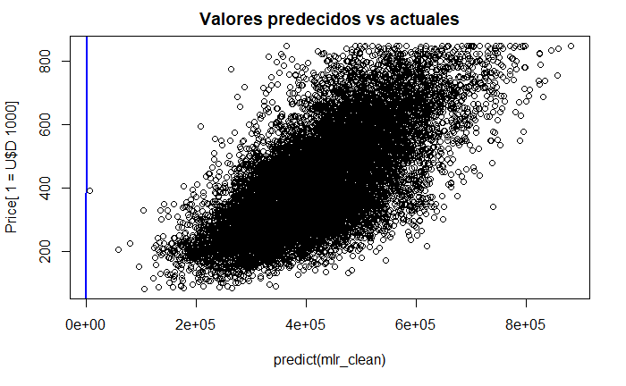

```r
plot(predict(mlr_clean),dataset.selection.clean$price/1000, ylab="Price[ 1 = U$D 1000]",
     main="Valores predecidos vs actuales",
abline(a=0,b=1,col="blue",lwd=2))
```

### Residuales

Podemos decir que en general es una buena gráfica, mejor que la obtenida con el dataset anterior ya que se eliminaron los puntos alejados. Sin embargo, aparecieron nuevos puntos, los cuales se pueden analizar y limpiar.

```r
plot(residuals(mlr_clean))
abline(a=0,b=0,col="blue",lwd=2)
```

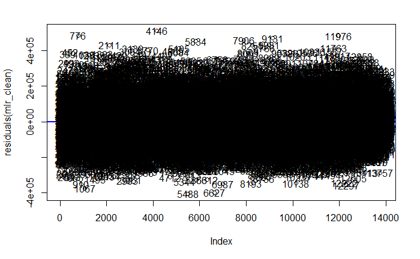

```r
text(residuals(mlr_clean))
```

### Ploteo del Modelo

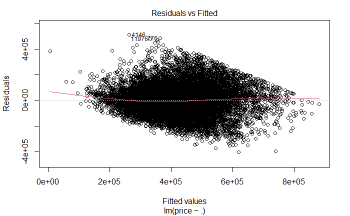

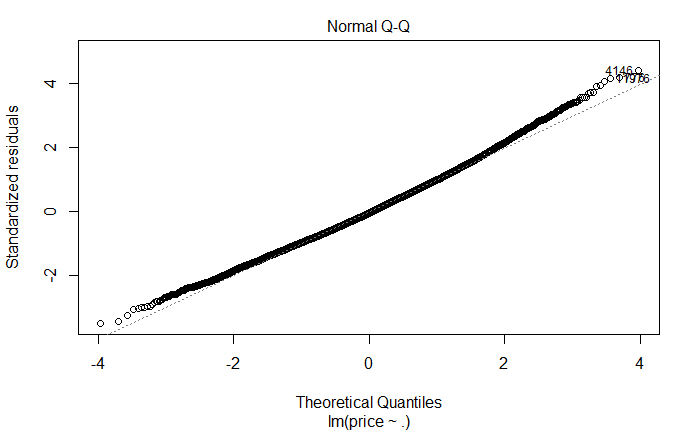

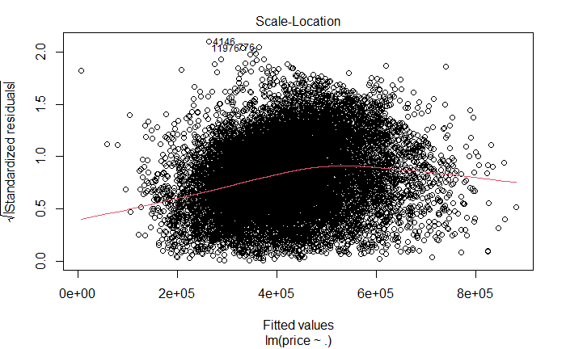

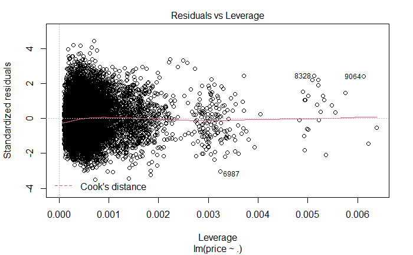

```r
plot(mlr_clean)
```

### Histograma de Residuales

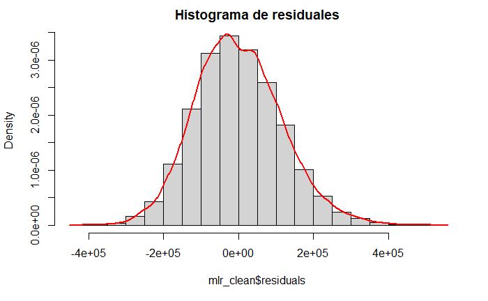

```r
hist(mlr_clean$residuals,main="Histograma de residuales",freq=F)
lines(density(mlr_clean$residuals),col = "red",lwd=2)
```

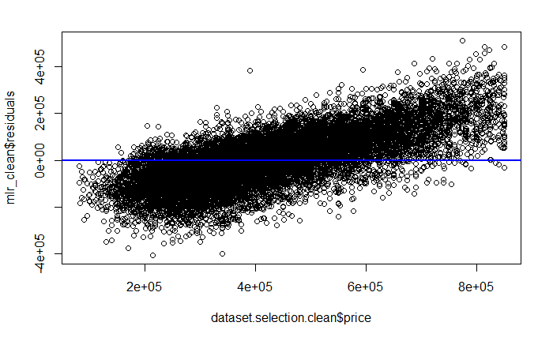

```r
plot(mlr_clean$residuals ~ dataset.selection.clean$price)
abline(a=0,b=0,col="blue",lwd=2)
```

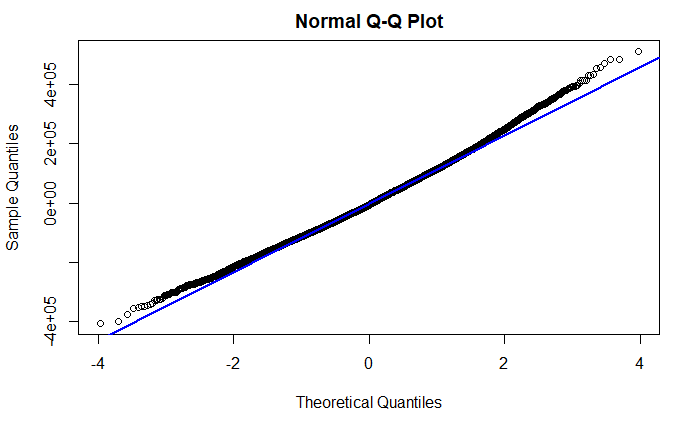

```r
qqnorm(mlr_clean$residuals)

qqline(mlr_clean$residuals,col="blue",lwd=2)
```